# TASK LEVEL 1A

# task 6b

##### 1 .declare a function even and odd .............................in that range.

```python
def odd_and_even(n):
    t=0
    t1=0
    for i in range(n+1):
        if i %2 ==0:
            t+=1
        elif i%2 !=0:
            t1+=1

    print('sum of odd no is',t)
    print('sum of odd no is',t1)
odd_and_even(100)
```

[output not shown]

##### 2 call your function factorial ......................................................................factorial of the number

```python
def factorial(n):
    if n==1:
        return 1
    else:
        return(n*factorial(n-1))

factorial(4)
```

```
24
```

##### 3 call your function is empty .............................................................it is empty or not

```python
def is_empty(empty):
    if len(empty)==0:
        print('it is empty')
    else:
        print('it is not empty')

is_empty([])
```

```
it is empty
```

##### 4.write diffrence function which take list ........................................calculate std.

```python
def mean(lis):
    mean = sum(lis)/len(lis)
    print(mean)

def median(lis):
        n = len(lis)
        meadian = n//2
        if n%2:
            return sorted(lis)[meadian]
        return sum(sorted(lis)[meadian-1:meadian+1])/2

from collections import Counter
def mode(lis):
    c =Counter(lis)
    return [k for k ,v in c.items() if v ==c.most_common(1)[0][1]]

def rang(lis):
    minimum = min(lis)
    maximum = max(lis)
    r = minimum - maximum
    return minimum,maximum,r

def standard_deviation(lis):
    sum = 0
    for i in range (len(lis)):
        sum +=lis[i]




print(mean([4,5,6,7]))
print(median([4,5,6,7,8]))
print(mode([3,4,5,6,7,8,9,8]))
print(rang([4,2,3,4,1,5,6]))
```

```
5.5
None
6
[8]
(1, 6, -5)
```

```python
import math
def std(lis):
    mean = sum (lis)/len(lis)
    var = sum (pow(x-mean,2) for x in lis)/len(lis)
    std = math.sqrt(var)
    print('mean',mean,'var',var,'std',std)
std([6,7,8,9])
```

```
mean 7.5 var 1.25 std 1.118033988749895
```

# task 6c

##### 1.write a function called is prime .....................number is prime .

```python
def prime_number(num):
    if num>1:
        for i in range(2,num):
            if (num% i)==0:
                print(num,'num is not a prime number')
                print(i,'times',num//i,'is ',num)
                break
            else:
                print(num,'is prime numbar')

    else:
        print(num,'is not a prime number')

prime_number(11)
```

```
11 is prime numbar
11 is prime numbar
11 is prime numbar
11 is prime numbar
11 is prime numbar
11 is prime numbar
11 is prime numbar
11 is prime numbar
11 is prime numbar
```

##### 2 write a function which checks if all are unique in the list.

```python
def unique(lis):
    a= set(lis)
    new = (list(a))

    for item in new:
        print(item)

unique([4,5,6,6,7,8,3,9,9,1,22,34])
```

```
1
34
3
4
5
6
7
8
9
22
```

##### 3.write a function which checks if all ................................................................same data type .

```python
def check_type(lis):
    res =True
    for i in lis:
        if not isinstance(i,type(lis[0])):
            res = False
            break
    print('do all element have a same type :'+str(res))
check_type([1,2,3,4])
```

```
do all element have a same type :True
```

##### 4.write a function which checks if provided variable is a valid variable

```python
def valid_variable(a):
    if a.isidentifier():
        print('it is a valid variable')
    else:
        print('it is not a valid variable')

valid_variable('2name')
```

```
it is not a valid variable
```

##### 5 go to the data folder and access the countries data py file

create a function called the most spoken languages ...................................................in the decending order

```python
import countries_data
from countries_data import data
t=[]
for countries in data:
    t.append(countries['languages'])

print(t)
len(t)

import pandas as pd

count = pd.Series(t).value_counts().sort_values(ascending=False)
count
```

```
[['Pashto', 'Uzbek', 'Turkmen'], ['Swedish'], ['Albanian'], ['Arabic'], ['English', 'Samoan'], ['Catalan'], ['Portuguese'], ['English'], ['English', 'Russian'], ['English'], ['Spanish', 'Guaraní'], ['Armenian', 'Russian'], ['Dutch', '(Eastern) Punjabi'], ['English'], ['German'], ['Azerbaijani'], ['E…
```

```
[English]                             50
[French]                              20
[Spanish]                             17
[Arabic]                              16
[Portuguese]                           8
                                      ..
[Turkmen, Russian]                     1
[Ukrainian]                            1
[Uzbek, Russian]                       1
[Bislama, English, French]             1
[English, Shona, Northern Ndebele]     1
Length: 126, dtype: int64
```

# task 7a

##### 1 . write a function which genrate a six .........................................................random user id.

```python
import random
def rand(n):
    rand = ['id:'+''.join([random.choice(n) for i in range(6)])]
    print(rand)

rand('abcdef0123456789')
```

```
['id:e03323']
```

##### 2. modify the previous task .................................................are suppose to be genrate.

```python
import secrets
import string

def s(a,b):
    for res in range (a):
        res  = ''.join(secrets.choice(string.ascii_uppercase+string.digits)for i in range (b))
        print('id:'+str(res))

a = int(input('enter a no'))
b = int(input('enter a no'))

print(s(a,b))
```

```
enter a no5
enter a no5
id:8BOYL
id:I1IJL
id:5VMPZ
id:1A6XV
id:H4K4H
None
```

```python
import secrets
import string

def s(a,b):
    for res in range (a):
        res  = ''.join(secrets.choice(string.ascii_uppercase+string.digits)for i in range (b))
        print('id:'+str(res))

a = int(input('enter a no'))
b = int(input('enter a no'))

print(s(a,b))
```

```
enter a no5
enter a no16
id:YQE5KUM8FZB1TBIZ
id:ZSVKUZVRUVAY3S7H
id:L5YDHYHBB3DVNDW7
id:RT36VF23XLJ99FEP
id:0IAO9PLN66Q6Z0L6
None
```

##### 3. write a function named rgb colors .............................................

```python
import random
def rgb_colors(a):
    r = random.randint(0,a)
    g = random.randint(0,a)
    b = random.randint(0,a)
    rgb = [r,g,b]
    print(' a random RGB value:rgb',rgb)

rgb_colors(255)
```

```
 a random RGB value:rgb [15, 210, 110]
```

# task 7b

##### 1 write a function list of hexa colors gen ....................................................................in an array

```python
import secrets
import string
import numpy as np
def list_of_hexa(a,b):
    x=[]
    for res in range (a):
        res  ='#'+ ''.join(secrets.choice(string.ascii_uppercase+string.digits)for i in range (b))
        x.append(res)
    y = np.array(x)
    return (y)

list_of_hexa(15,7)
```

```
array(['#88BKDZC', '#CQFRH28', '#F6PHWBA', '#OZKLIV1', '#2DR1EIW',
       '#WBZFHHI', '#BJ9LI2T', '#TRUX2G4', '#X0P3774', '#WMSRA7Q',
       '#ZYK8Q39', '#S22R388', '#WV8TL3L', '#0BO2QKG', '#S821VQ4'],
      dtype='<U8')
```

##### 2 write a function list of rgb ................................................................................in an array

```python
import random
import numpy as np
def lsit_of_rgb():
    x=[]
    for i in range(13):

        r = random.randint(0,255)
        g = random.randint(0,255)
        b = random.randint(0,255)
        rgb ='rgb ({},{},{})'.format(r,g,b)
        x.append(rgb)
    y=np.array(x)
    return y

lsit_of_rgb()
```

```
array(['rgb (216,214,205)', 'rgb (134,97,108)', 'rgb (143,85,78)',
       'rgb (87,68,228)', 'rgb (146,3,253)', 'rgb (225,224,213)',
       'rgb (31,244,27)', 'rgb (194,94,77)', 'rgb (209,166,20)',
       'rgb (141,18,38)', 'rgb (97,138,23)', 'rgb (233,16,220)',
       'rgb (83,223,189)'], dtype='<U17')
```

##### 3 write a function genrate colors .............................................................hexa or rbg colors

```python
def genrate_colors(type1,z):
    if type1 =='rgb':
        x=[]
        for i in range(z):

            r = random.randint(0,255)
            g = random.randint(0,255)
            b = random.randint(0,255)
            rgb ='rgb ({},{},{})'.format(r,g,b)
            x.append(rgb)
        y=np.array(x)
        return y

    elif type1 =='hex':
        x=[]
        for res in range (z):
            res  ='#'+ ''.join(secrets.choice(string.ascii_uppercase+string.digits)for i in range (7))
            x.append(res)
        y = np.array(x)
        return (y)

    else:
        pass


genrate_colors('rgb',5)
```

```
array(['rgb (68,28,0)', 'rgb (66,207,34)', 'rgb (34,148,232)',
       'rgb (215,43,78)', 'rgb (253,17,131)'], dtype='<U16')
```

# task 7c

##### 1 call your function shuffle_list...............................................................shuffled list

```python
def shuffle_list(lis):
    random.shuffle(lis)
    print(lis)


shuffle_list([3,4,5,65,4,533,23,13,56])
```

```
[56, 5, 13, 23, 4, 4, 533, 3, 65]
```

##### 2 write a function which returns an array ......................................................must be unique

```python
def random_number(a,b):
    ran =random.sample(range(a,b),9)
    print(ran)

random_number(0,9)
```

```
[2, 7, 8, 5, 4, 1, 6, 3, 0]
```

# task 8a

##### 1 filter only negative and zero.............................................................comprehension

```python
num=[-4,-3,-2,-1,0,2,4,6]
negative_zero = [i for i in (num) if i<=0 or i==0]
negative_zero
```

```
[-4, -3, -2, -1, 0]
```

##### 2 flatten the follwing list of list ...............................................................dimentioanl list

```python
list_of_list=[[[1,2,3]],[[4,5,6]],[[7,8,9]]]
x = [x for sublist in list_of_list  for x in sublist ]
new= [i for sublist in x  for i in sublist ]
new
```

```
[1, 2, 3, 4, 5, 6, 7, 8, 9]
```

##### 3 using list compresiation create following list of tuple

```python
lis = [0,1,2,3,4,5,6,7,8,9,10]
for i in range(1):
    lis_1=[(j,j**0,j**1,j**2,j**3,j**4,j**5) for j in lis]
    print(lis_1)
```

```
[(0, 1, 0, 0, 0, 0, 0), (1, 1, 1, 1, 1, 1, 1), (2, 1, 2, 4, 8, 16, 32), (3, 1, 3, 9, 27, 81, 243), (4, 1, 4, 16, 64, 256, 1024), (5, 1, 5, 25, 125, 625, 3125), (6, 1, 6, 36, 216, 1296, 7776), (7, 1, 7, 49, 343, 2401, 16807), (8, 1, 8, 64, 512, 4096, 32768), (9, 1, 9, 81, 729, 6561, 59049), (10, 1, 1…
```

##### 4 flatten the flowing list to new list

```python
list_of_list=[[['finland','helsink']],[['sweden','stockhome']],[['norway','oslo']]]
x = [x for sublist in list_of_list for x in sublist ]
x
```

```
[['finland', 'helsink'], ['sweden', 'stockhome'], ['norway', 'oslo']]
```

##### 5 change the list to list of the dictionary

```python
countries=[[('finland','helsink')],[('sweden','stockh')],[('norway','oslo')]]
key_list = ['name','number']
n = len(countries)
res = []
for i in range(0,n,1):
    res.append({key_list[0][0]:countries[i],key_list[0][1]:countries[i+1]})

    print('countries dictionary :'+str(res))
```

```
countries dictionary :[{'n': [('finland', 'helsink')], 'a': [('sweden', 'stockh')]}]
countries dictionary :[{'n': [('finland', 'helsink')], 'a': [('sweden', 'stockh')]}, {'n': [('sweden', 'stockh')], 'a': [('norway', 'oslo')]}]
```

[output not shown]

##### 6 cahnge the following list of list of concatenatd string

```python
list_of_list = [[('mann','sir')],[('devid','smith')],[('donald','trump')],[('bill','gates')]]
list1 = []
for i in list_of_list:
    for j in i:
        element = j[0]+' '+j[1]
        list1.append(element)
list1
```

```
['mann sir', 'devid smith', 'donald trump', 'bill gates']
```

##### 7 write a lambda function which can solve a slope ...........................................function

```python
import math
x = lambda x1,y1,x2,y2 : ((y2-y1)/(x2-x1))
print(x(3,4,5,6))
```

```
1.0
```

# task 8a

##### 2 explane the diffrence between higher order function ,closure and decorator

higher_order_function : A function can act as an instant of an objects type. we can return a function as a result of a another function. in higher order function we can pass a function as a parameter or argument inside another function. closure function: a closure is the combination of a function bundled together with refrences to its surrounding state. a closure gives you access to an outer function scope from an inner function. decoder function: this method is used to convert from one ecoding scheme, in which argument string is encoding scheme. this works opposite to the encoding. it accepts the encoding of the encoding string to decode it and return the original string.

##### 3 define a call function before map, fillter or reduce ,see example

##### 4 use for loop to print .......................land

```python
countries = ['estonia','finland','sweden','denmark','norway','icelamd']
n =list(map(lambda k: k , countries))
n
```

```
['estonia', 'finland', 'sweden', 'denmark', 'norway', 'icelamd']
```

```python
for i in countries:
    print(i)
```

```
estonia
finland
sweden
denmark
norway
icelamd
```

##### 5 use for to...........................................list

```python
name = ['ababeneh','lidiya','ermias','abraham']
for i in name:
    print(i)
```

```
ababeneh
lidiya
ermias
abraham
```

##### 6use for ..................................................list

```python
number=[-4,-3,-2,-1,0,2,4,6]
for i in number:
    print(i)
```

```
-4
-3
-2
-1
0
2
4
6
```

# task 9b

##### 1use map to create .............................................countries list

```python
new = list(map(lambda x: x.upper (),['estonia','finland','sweden','denmark','norway','icelamd']))
new
```

```
['ESTONIA', 'FINLAND', 'SWEDEN', 'DENMARK', 'NORWAY', 'ICELAMD']
```

##### 2use map to ...............................................number list

```python
number=[-4,-3,-2,-1,0,2,4,6]

num = list(map(lambda x:x**2 ,number))
num
```

```
[16, 9, 4, 1, 0, 4, 16, 36]
```

##### 3 use map .........................name list

```python
name = ['sai','ram','radha','krishana','mahadev']
n = list(map(lambda x:x.upper(),name))
n
```

```
['SAI', 'RAM', 'RADHA', 'KRISHANA', 'MAHADEV']
```

##### 4 use filtter ........................land

```python
new = list(filter(lambda k: 'land' in k, ['estonia','finland','sweden','denmark','norway','icelamd']))
new
```

```
['finland']
```

##### 5 use filtter ............................six charactors

```python
new = list(filter(lambda k:len(k)==6, ['estonia','finland','sweden','denmark','norway','icelamd']))
new
```

```
['sweden', 'norway']
```

##### 6 us efiltter ......................................country list

```python
new = list(filter(lambda k:len(k)>=6, ['estonia','finland','sweden','denmark','norway','icelamd']))
new
```

```
['estonia', 'finland', 'sweden', 'denmark', 'norway', 'icelamd']
```

##### 7 use filtter to ................................................with an E

```python
start = 'e'
new = list(filter(lambda k:k.startswith(start), ['estonia','finland','sweden','denmark','norway','icelamd']))
new
```

```
['estonia']
```

##### 8 chain two or more ...............................................reduce

##### 9 declare a function .........................................only string item

```python
def get_string_list(list1):
    a = []
    string = 'str'
    for i in list1:
        if type(i) == type(string):
             a.append(i)
        else:
            pass

    print(a)
B = [ 'z',3 , 'e', 'r' , 'u' ,5,6,7]
get_string_list(B)
```

```
['z', 'e', 'r', 'u']
```

##### 10 use reduce to sum ...................list

```python
number = [1,2,3,4,5,6,7,8,9]
import functools
print(functools.reduce(lambda a,b:a+b,number))
```

```
45
```

##### 11 use reduce to concatenate ........................ countries

```python
countries = ['estonia','finland','sweden','denmark','norway','icelamd']
v = (functools.reduce(lambda x,y:x+' '+','+y,countries))
print(v,'are north european countries')
```

```
estonia ,finland ,sweden ,denmark ,norway ,icelamd are north european countries
```

```python
import countries_data
from countries_data import data
country=[]
for i in data:
    c=i['name']
    country.append(c)
len(data)
```

```
250
```

##### 12 declare a function ............... '

```python
def categorize_countries(a):
    land=[]
    ia=[]
    island=[]
    stan=[]
    for i in a:
        b= 'land' in i
        c= 'ia' in i
        d= 'island' in i
        e='stan' in i
        if b==True:
            land.append(i)
        elif c==True:
            ia.append(i)
        elif d==True:
            island.append(i)
        elif e==True:
            stan.append(i)
        else:
            pass
    print('1) Contries containing land in their name: ', land)
    print('2) Contries containing ia in their name: ', ia)
    print('3) Contries containing island in their name: ', island)
    print('4) Contries containing stan in their name: ', stan)
categorize_countries(country)
```

```
1) Contries containing land in their name:  ['Åland Islands', 'Bouvet Island', 'United States Minor Outlying Islands', 'Virgin Islands (British)', 'Virgin Islands (U.S.)', 'Cayman Islands', 'Christmas Island', 'Cocos (Keeling) Islands', 'Cook Islands', 'Falkland Islands (Malvinas)', 'Faroe Islands',…
2) Contries containing ia in their name:  ['Albania', 'Algeria', 'Armenia', 'Australia', 'Austria', 'Bolivia (Plurinational State of)', 'Bosnia and Herzegovina', 'British Indian Ocean Territory', 'Bulgaria', 'Cambodia', 'Colombia', 'Croatia', 'Equatorial Guinea', 'Estonia', 'Ethiopia', 'French Guian…
3) Contries containing island in their name:  []
4) Contries containing stan in their name:  ['Afghanistan', 'Kazakhstan', 'Kyrgyzstan', 'Pakistan', 'Saint Helena, Ascension and Tristan da Cunha', 'Tajikistan', 'Turkmenistan', 'Uzbekistan']
```

##### 13 create a function ................ letter

```python
letter = ['A','B','C','D','E','F','G','H','I','J','K','L','M','N','O','P','Q','R','S','T','U','V','W','X','Y','Z']
def cat_country(a):
    Dict1= {}
    Dict2= {}
    for i in letter:
        Dict1[i]=[]

    for i in letter:
        Dict2[i]=[]
    for i in letter:
        for a in country:
            if a[0]==i:
                d=Dict1[i]
                d.append(a)
            else:
                pass
    for i in Dict1:
        d=Dict1[i]
        Dict2[i]=len(d)
    print(Dict2)
cat_country(country)
```

```
{'A': 15, 'B': 21, 'C': 23, 'D': 4, 'E': 7, 'F': 8, 'G': 16, 'H': 6, 'I': 9, 'J': 4, 'K': 7, 'L': 9, 'M': 23, 'N': 13, 'O': 1, 'P': 12, 'Q': 1, 'R': 5, 'S': 33, 'T': 14, 'U': 8, 'V': 5, 'W': 2, 'X': 0, 'Y': 1, 'Z': 2}
```

##### 14 declare a get first list....................................data folder

```python
def get_ten_countries(a):
    import json
    f = open(a)
    import pandas as pd
    df = pd.read_json(a)
    country = df['name']
    list1 = list(country)
    print(list1[:10])
get_ten_countries("countries_data.json")
```

```
['Afghanistan', 'Åland Islands', 'Albania', 'Algeria', 'American Samoa', 'Andorra', 'Angola', 'Anguilla', 'Antarctica', 'Antigua and Barbuda']
```

##### 15 declare a get last ten.........................countries list

```python
def get_last_ten_countries(a):
    import json
    f = open(a)
    import pandas as pd
    df = pd.read_json(a)
    country = df['name']
    list1=list(country)
    d= len(list1)
    print(list1[d-10:])
get_last_ten_countries('countries_data.json')
```

```
['Uruguay', 'Uzbekistan', 'Vanuatu', 'Venezuela (Bolivarian Republic of)', 'Viet Nam', 'Wallis and Futuna', 'Western Sahara', 'Yemen', 'Zambia', 'Zimbabwe']
```

# task 9c

##### 1 use the countries .............

sort countries by name by capital .........

```python
import countries_data
from countries_data import data
import pandas as  pd
d = pd.DataFrame(data)
capital=d.sort_values(['capital'],ascending=(True))
name=d.sort_values(['name'],ascending=(True))
population=d.sort_values(['population'],ascending=(False))
```

```python
capital
```

|  | name | capital | languages | population | flag | currency |
| --- | --- | --- | --- | --- | --- | --- |
| 33 | United States Minor Outlying Islands |  | [English] | 300 | https://restcountries.eu/data/umi.svg | United States Dollar |
| 131 | Macao |  | [Chinese, Portuguese] | 649100 | https://restcountries.eu/data/mac.svg | Macanese pataca |
| 30 | Bouvet Island |  | [Norwegian, Norwegian Bokmål, Norwegian Nynorsk] | 0 | https://restcountries.eu/data/bvt.svg | Norwegian krone |
| 8 | Antarctica |  | [English, Russian] | 1000 | https://restcountries.eu/data/ata.svg | Australian dollar |
| 98 | Heard Island and McDonald Islands |  | [English] | 0 | https://restcountries.eu/data/hmd.svg | Australian dollar |
| ... | ... | ... | ... | ... | ... | ... |
| 106 | Côte d'Ivoire | Yamoussoukro | [French] | 22671331 | https://restcountries.eu/data/civ.svg | West African CFA franc |
| 41 | Cameroon | Yaoundé | [English, French] | 22709892 | https://restcountries.eu/data/cmr.svg | Central African CFA franc |
| 155 | Nauru | Yaren | [English, Nauruan] | 10084 | https://restcountries.eu/data/nru.svg | Australian dollar |
| 11 | Armenia | Yerevan | [Armenian, Russian] | 2994400 | https://restcountries.eu/data/arm.svg | Armenian dram |
| 57 | Croatia | Zagreb | [Croatian] | 4190669 | https://restcountries.eu/data/hrv.svg | Croatian kuna |

250 rows × 6 columns

```python
name
```

|  | name | capital | languages | population | flag | currency |
| --- | --- | --- | --- | --- | --- | --- |
| 0 | Afghanistan | Kabul | [Pashto, Uzbek, Turkmen] | 27657145 | https://restcountries.eu/data/afg.svg | Afghan afghani |
| 2 | Albania | Tirana | [Albanian] | 2886026 | https://restcountries.eu/data/alb.svg | Albanian lek |
| 3 | Algeria | Algiers | [Arabic] | 40400000 | https://restcountries.eu/data/dza.svg | Algerian dinar |
| 4 | American Samoa | Pago Pago | [English, Samoan] | 57100 | https://restcountries.eu/data/asm.svg | United State Dollar |
| 5 | Andorra | Andorra la Vella | [Catalan] | 78014 | https://restcountries.eu/data/and.svg | Euro |
| ... | ... | ... | ... | ... | ... | ... |
| 246 | Western Sahara | El Aaiún | [Spanish] | 510713 | https://restcountries.eu/data/esh.svg | Moroccan dirham |
| 247 | Yemen | Sana'a | [Arabic] | 27478000 | https://restcountries.eu/data/yem.svg | Yemeni rial |
| 248 | Zambia | Lusaka | [English] | 15933883 | https://restcountries.eu/data/zmb.svg | Zambian kwacha |
| 249 | Zimbabwe | Harare | [English, Shona, Northern Ndebele] | 14240168 | https://restcountries.eu/data/zwe.svg | Botswana pula |
| 1 | Åland Islands | Mariehamn | [Swedish] | 28875 | https://restcountries.eu/data/ala.svg | Euro |

250 rows × 6 columns

```python
population
```

|  | name | capital | languages | population | flag | currency |
| --- | --- | --- | --- | --- | --- | --- |
| 48 | China | Beijing | [Chinese] | 1377422166 | https://restcountries.eu/data/chn.svg | Chinese yuan |
| 104 | India | New Delhi | [Hindi, English] | 1295210000 | https://restcountries.eu/data/ind.svg | Indian rupee |
| 239 | United States of America | Washington, D.C. | [English] | 323947000 | https://restcountries.eu/data/usa.svg | United States dollar |
| 105 | Indonesia | Jakarta | [Indonesian] | 258705000 | https://restcountries.eu/data/idn.svg | Indonesian rupiah |
| 31 | Brazil | Brasília | [Portuguese] | 206135893 | https://restcountries.eu/data/bra.svg | Brazilian real |
| ... | ... | ... | ... | ... | ... | ... |
| 80 | French Southern Territories | Port-aux-Français | [French] | 140 | https://restcountries.eu/data/atf.svg | Euro |
| 177 | Pitcairn | Adamstown | [English] | 56 | https://restcountries.eu/data/pcn.svg | New Zealand dollar |
| 209 | South Georgia and the South Sandwich Islands | King Edward Point | [English] | 30 | https://restcountries.eu/data/sgs.svg | British pound |
| 30 | Bouvet Island |  | [Norwegian, Norwegian Bokmål, Norwegian Nynorsk] | 0 | https://restcountries.eu/data/bvt.svg | Norwegian krone |
| 98 | Heard Island and McDonald Islands |  | [English] | 0 | https://restcountries.eu/data/hmd.svg | Australian dollar |

250 rows × 6 columns

##### - sort out the ten most .........

```python
list_pop = list(population['name'])
print("The 10 most populated countries in the world: ")
f_10 = list(list_pop[:10])
for i in f_10:
    print(i)
```

```
The 10 most populated countries in the world:
China
India
United States of America
Indonesia
Brazil
Pakistan
Nigeria
Bangladesh
Russian Federation
Japan
```

# task 10a:

##### 1 get the current day , year ,hour ..........

```python
import datetime
```

```python
from datetime import datetime as dt
```

```python
now = datetime.datetime.now ()
time = now.timestamp()
time
```

```
1664386662.79646
```

```python
day = print(now.day,'/',now.hour,'/',now.year)
day
```

```
28 / 23 / 2022
```

##### 2 format the current date

```python
time = now.strftime('%m:%d%Y:%H:%M:%S')
time
```

```
'09:282022:23:07:42'
```

##### 3today is 20............

```python
from datetime import datetime
time = '20 August, 2022'
new = datetime.strptime(time,"%d %B, %Y")
print(new)
```

```
2022-08-20 00:00:00
```

##### calculate the time...............

```python
from datetime import date
today = date(year = 2022,month= 9,day = 22)
nw_year = date(year= 2023,month = 1,day=1)
new = nw_year-today
new
```

```
datetime.timedelta(days=101)
```

##### 5 calculate the time diffrence,........................

```python
from datetime import date
today = date(year = 1970,month= 1,day = 1)
nw_year = date(year= 2023,month = 1,day=1)
new = nw_year-today
new
```

```
datetime.timedelta(days=19358)
```

# task 11a

##### write a function which count...................

###### a read obama apeech................

```python
file = open('C:/Users/Rushi/Desktop/data for ready2code/obama_speech.txt','r')
file
```

```
<_io.TextIOWrapper name='C:/Users/Rushi/Desktop/data for ready2code/obama_speech.txt' mode='r' encoding='cp1252'>
```

```python
file1 = open ("C:/Users/Rushi/Desktop/data for ready2code/obama_speech.txt").read()
```

```python
file1
```

```
'My fellow citizens:I stand here today humbled by the task before us, grateful for the trust you have bestowed, mindful of the sacrifices borne by our ancestors. I thank President Bush for his service to our nation, as well as the generosity and cooperation he has shown throughout this transition.\n…
```

```python
no_of_line= 0
no_of_word =0
no_of_charectres = 0

for line in file:
    line=line.strip('\n')


    word = line.split()
    no_of_line +=1
    no_of_word +=len(word)

file.close()
print('lines:',no_of_line,'word',no_of_word)
```

```
lines: 66 word 2400
```

###### b read michelle obama speech .....................

```python
file1 = open('C:/Users/Rushi/Desktop/data for ready2code/michelle_obama_speech.txt','r')
```

```python
file1
```

```
<_io.TextIOWrapper name='C:/Users/Rushi/Desktop/data for ready2code/michelle_obama_speech.txt' mode='r' encoding='cp1252'>
```

```python
no_of_line= 0
no_of_word =0
no_of_charectres = 0

for line in file1:
    line=line.strip('\n')


    word = line.split()
    no_of_line +=1
    no_of_word +=len(word)
    no_of_charectres +=len(line)

file1.close()
print('lines:',no_of_line,'word',no_of_word,'charectors',no_of_charectres)
```

```
lines: 83 word 2204 charectors 11707
```

###### d. read melian trump...................

```python
trump = open('C:/Users/Rushi/Desktop/data for ready2code/melina_trump_speech.txt','r')
trump
```

```
<_io.TextIOWrapper name='C:/Users/Rushi/Desktop/data for ready2code/melina_trump_speech.txt' mode='r' encoding='cp1252'>
```

```python
for line in trump:
    line=line.strip('\n')


    word = line.split()
    no_of_line +=1
    no_of_word +=len(word)
    no_of_charectres +=len(line)

trump.close()
print('lines:',no_of_line,'word',no_of_word,'charectors',no_of_charectres)
```

[output not shown]

##### 2 read the countries data json data .......................

```python
import pandas as pd
df = pd.read_json('C:/Users/Rushi/Desktop/data for ready2code/countries_data.json')
df
```

|  | name | capital | languages | population | flag | currency |
| --- | --- | --- | --- | --- | --- | --- |
| 0 | Afghanistan | Kabul | [Pashto, Uzbek, Turkmen] | 27657145 | https://restcountries.eu/data/afg.svg | Afghan afghani |
| 1 | Åland Islands | Mariehamn | [Swedish] | 28875 | https://restcountries.eu/data/ala.svg | Euro |
| 2 | Albania | Tirana | [Albanian] | 2886026 | https://restcountries.eu/data/alb.svg | Albanian lek |
| 3 | Algeria | Algiers | [Arabic] | 40400000 | https://restcountries.eu/data/dza.svg | Algerian dinar |
| 4 | American Samoa | Pago Pago | [English, Samoan] | 57100 | https://restcountries.eu/data/asm.svg | United State Dollar |
| ... | ... | ... | ... | ... | ... | ... |
| 245 | Wallis and Futuna | Mata-Utu | [French] | 11750 | https://restcountries.eu/data/wlf.svg | CFP franc |
| 246 | Western Sahara | El Aaiún | [Spanish] | 510713 | https://restcountries.eu/data/esh.svg | Moroccan dirham |
| 247 | Yemen | Sana'a | [Arabic] | 27478000 | https://restcountries.eu/data/yem.svg | Yemeni rial |
| 248 | Zambia | Lusaka | [English] | 15933883 | https://restcountries.eu/data/zmb.svg | Zambian kwacha |
| 249 | Zimbabwe | Harare | [English, Shona, Northern Ndebele] | 14240168 | https://restcountries.eu/data/zwe.svg | Botswana pula |

250 rows × 6 columns

```python
def most_spoken_languages(a,b):
    import json
    f = open(a)
    import pandas as pd
    df = pd.read_json(a)
    lan = df['languages']
    list3 = list(lan)
    all_languages=[]
    for i in list3:
        for a in i:
            all_languages.append(a)
    count = pd.Series(all_languages).value_counts().sort_values(ascending = False).head(b)
    print(count)
```

```python
most_spoken_languages('countries_data.json',10)
```

```
English       91
French        45
Arabic        25
Spanish       24
Portuguese     9
Russian        9
Dutch          8
German         7
Chinese        5
Serbian        4
dtype: int64
```

##### 3 read the countries data...................................

```python
def most_populated_countries(a,c):
    import json
    f = open(a)
    import pandas as pd
    df = pd.read_json(a)
    pop = df['population']
    list4=list(pop)
    name= df['name']
    list5=list(name)
    count = pd.Series(pop).sort_values(ascending = False).head(c)
    count_10=list(count)
    name_10=[]
    for i in count:
        b = list4.index(i)
        name_10.append(list5[b])
    final_list=[]
    for i in name_10:
        t=[]
        t.append(i)
        final_list.append(t)
    final_list
    list_of_tuples = list(zip(name_10,count_10))
    final_dict=[]
    for i in list_of_tuples:
        d=i
        dict3=dict(zip(['country','population'],d))
        final_dict.append(dict3)
    print(final_dict)
most_populated_countries('countries_data.json',10)
```

```
[{'country': 'China', 'population': 1377422166}, {'country': 'India', 'population': 1295210000}, {'country': 'United States of America', 'population': 323947000}, {'country': 'Indonesia', 'population': 258705000}, {'country': 'Brazil', 'population': 206135893}, {'country': 'Pakistan', 'population': …
```

# task 11b

##### 1 extract all incoming email ...............................

```python
file = open('email_exchanges_big.txt','rt')
file
```

```
<_io.TextIOWrapper name='email_exchanges_big.txt' mode='rt' encoding='cp1252'>
```

```python
import re
for line in file:
    if re.match(r'[\w\.-]+@[\w\.-]+',line):
        print(line)
```

[output not shown]

[output cut: 12 more lines]

```
dhorwitz@david-horwitz-6:~/branchManagemnt/sakai_2-5-x> svn merge -c39194 https://source.sakaiproject.org/svn/message/trunk message/

dhorwitz@david-horwitz-6:~/branchManagemnt/sakai_2-5-x> svn merge -c39195 https://source.sakaiproject.org/svn/portal/trunk portal/

dhorwitz@david-horwitz-6:~/branchManagemnt/sakai_2-5-x> svn merge -c39196 https://source.sakaiproject.org/svn/login/trunk login/

dhorwitz@david-horwitz-6:~/branchManagemnt/sakai_2-5-x> svn merge --dry-run -r39522:39522 https://source.sakaiproject.org/svn/msgcntr/branches/sakai_2-5-x msgcntr/

dhorwitz@david-horwitz-6:~/branchManagemnt/sakai_2-5-x> svn merge --dry-run -r39522:39521 https://source.sakaiproject.org/svn/msgcntr/branches/sakai_2-5-x msgcntr/

dhorwitz@david-horwitz-6:~/branchManagemnt/sakai_2-5-x> svn merge  -r39522:39521 https://source.sakaiproject.org/svn/msgcntr/branches/sakai_2-5-x msgcntr/

dhorwitz@david-horwitz-6:~/branchManagemnt/sakai_2-5-x> svn merge  -r39522:39521 https://source.sakaiproject.org/svn/gradebook/branches/sakai_2-5-x gradebook/

dhorwitz@david-horwitz-6:~/branchManagemnt/sakai_2-5-x> svn merge -r39524:39525  https://source.sakaiproject.org/svn/reset-pass/trunk reset-pass/
```

##### 2 find the most commmon .................................

```python
def find_most_commen_words(A):
    with open(A) as f:
        lines = f.readlines()
    line=str(lines)
    split_list= line.split()
    alpha=[]
    for i in split_list:
        a= i.isalpha()
        if a==True:
            alpha.append(i)
    import pandas as pd
    count = pd.Series(alpha).value_counts().sort_values(ascending = False)
    print('10 most frequent words: ')
    print(count.head(10))
find_most_commen_words('obama_speech.txt')
```

```
10 most frequent words:
the     120
and     107
of       81
to       66
our      58
we       50
a        48
that     47
is       36
in       22
dtype: int64
```

##### 3 use the function find most requent ...............

###### the ten .........................obama speech

```python
def find_most_frequent_words(A):
    with open(A) as f:
        lines = f.readlines()
    line=str(lines)
    split_list= line.split()
    alpha=[]
    for i in split_list:
        a= i.isalpha()
        if a==True:
            alpha.append(i)
    import pandas as pd
    count = pd.Series(alpha).value_counts().sort_values(ascending = False)
    print('10 most frequent words: ')
    print(count.head(10))
find_most_frequent_words('obama_speech.txt')
```

```
10 most frequent words:
the     120
and     107
of       81
to       66
our      58
we       50
a        48
that     47
is       36
in       22
dtype: int64
```

###### b

```python
find_most_frequent_words('michelle_obama_speech.txt')
```

[output not shown]

###### c

```python
find_most_frequent_words('melina_trump_speech.txt')
```

[output not shown]

###### d

```python
find_most_frequent_words('romeo_and_juliet.txt')
```

```
10 most frequent words:
the     731
I       537
and     524
to      512
of      476
a       437
in      323
is      312
my      306
that    261
dtype: int64
```

```python
file = open
```

##### 6 read the hacker news

##### A count the number of list ...................

```python
read = open('hacker_news.csv',encoding = 'utf-8')
rows = 0


for record in read:
    if record.count('python') or record.count('Python')>0:
        rows +=1
print('{rows containining the word "python" or "Python": %d }' %(rows))
```

```
{rows containining the word "python" or "Python": 179 }
```

##### B count..............

```python
read = open('hacker_news.csv',encoding = 'utf-8')
rows = 0


for record in read:
    if record.count('javascript') or record.count('JavaScript') or record.count('Javascript') >0:
        rows +=1
print('{rows containining the word "python" or "Python": %d }' %(rows))
```

[output not shown]

##### c count the number

```python
read = open('hacker_news.csv',encoding = 'utf-8')
rows = 0


for record in read:
    if record.count('Java') >0:
        rows +=1
print('{rows containining the word "python" or "Python": %d }' %(rows))
```

[output not shown]

# task 12a

##### 1 python has the module ...............................output below

```python
import statistics as st
```

```python
help(st)
```

[output not shown]

[output cut: 527 more lines]

[output not shown]

```python
ages = [31,26,34,37,27,26,32,32,26,27,27,24,32,33,27,25,26,38,37,31,34,24,33,29,26]

class ststics:
    def __init__(self,mean):
        self.mean = mean

    def mean(self,ages):
        self.mean = sum(list(self.ages))/len(list(self.ages))
        print(self.mean)

#     def median(lis):
#             n = len(lis)
#             meadian = n//2
#             if n%2:
#                 return sorted(lis)[meadian]
#             return sum(sorted(lis)[meadian-1:meadian+1])/2

#     from collections import Counter
#     def mode(lis):
#         c =Counter(lis)
#         return [k for k ,v in c.items() if v ==c.most_common(1)[0][1]]

#     def rang(lis):
#         minimum = min(lis)
#         maximum = max(lis)
#         r = minimum - maximum
#         return minimum,maximum,r

#     def standard_deviation(lis):
#         sum = 0
#         for i in range (len(lis)):
#             sum +=lis[i]

#     function([4,5,6,7])
#     print(median([4,5,6,7]))
#     print(mode([3,4,5,6,7,8,9,8]))
#     print(rang([4,2,3,4,1,5,6]))

#     import math
#     def std(lis):
#         mean = sum (lis)/len(lis)
#         var = sum (pow(x-mean,2) for x in lis)/len(lis)
#         std = math.sqrt(var)
#         print('mean',mean,'var',var,'std',std)
#     std([6,7,8,9])


c=ststics(ages)
c.mean()
```

# task 12b

##### create a class personaccount............................expenses

[output not shown]

s =personacount('vaishali','gadekar')

# task 13a

##### create a word cloud..............

```python
import matplotlib.pyplot as plt
import pandas as pd
import numpy as np
from PIL import Image
```

```python
import urllib
```

```python
pip install wordcloud
```

[output not shown]

```python
from wordcloud import WordCloud,STOPWORDS
```

```python
read = open('C:/Users/Rushi/Desktop/data for ready2code/obama_speech.txt').read()
```

```python
read
```

```
'My fellow citizens:I stand here today humbled by the task before us, grateful for the trust you have bestowed, mindful of the sacrifices borne by our ancestors. I thank President Bush for his service to our nation, as well as the generosity and cooperation he has shown throughout this transition.\n…
```

```python
stopword = set(STOPWORDS)
```

```python
alic_wc = WordCloud(background_color='white',max_words=2000,stopwords=stopword)
```

```python
alic_wc.generate(read)
```

```
<wordcloud.wordcloud.WordCloud at 0x262c47adcc0>
```

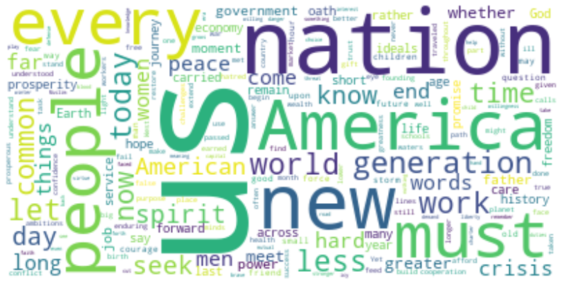

```python
stopword.add('will')
alic_wc.generate(read)
fig = plt.figure(figsize=(14,18))
plt.imshow(alic_wc,interpolation ='bilinear')
plt.axis('off')
plt.show()
```

# task 13b

##### 1 create a word ..................

```python
read = open('romeo_and_juliet.txt').read()
```

```python
read
```

```
'The Project Gutenberg EBook of Romeo and Juliet, by William Shakespeare\n\n\n*******************************************************************\nTHIS EBOOK WAS ONE OF PROJECT GUTENBERG\'S EARLY FILES PRODUCED AT A\nTIME WHEN PROOFING METHODS AND TOOLS WERE NOT WELL DEVELOPED. THERE\nIS AN IMPROVED…
```

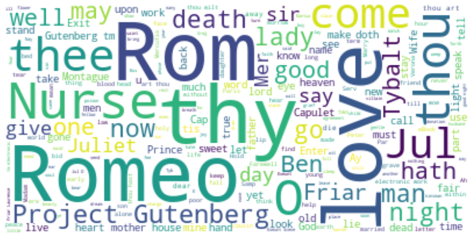

```python
stopword.add('will')
alic_wc.generate(read)
fig = plt.figure(figsize=(14,18))
plt.imshow(alic_wc,interpolation ='bilinear')
plt.axis('off')
plt.show()
```

```python
import urllib
```

```python
i = Image.open('rom_jul.png')
alice_mask = np.array(i)
```

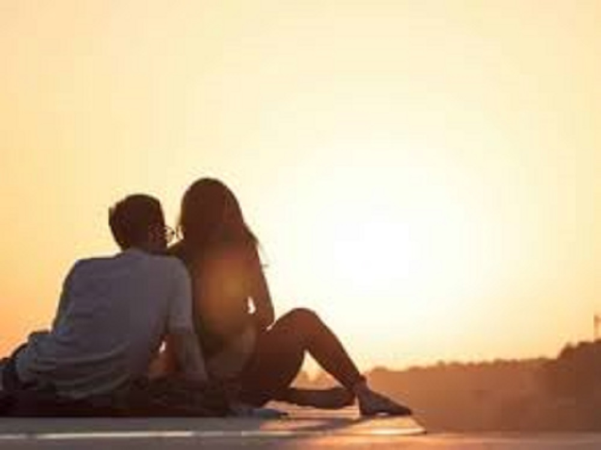

```python
i
```

```python
alic_wc = WordCloud(background_color='white',max_words=2000,stopwords=stopword)
```

```python
alic_wc
```

```python
from os import path
from PIL import Image
import numpy as np
import matplotlib.pyplot as plt
import os

from wordcloud import WordCloud, STOPWORDS, ImageColorGenerator

# get data directory (using getcwd() is needed to support running example in generated IPython notebook)
d = path.dirname(_file) if "file_" in locals() else os.getcwd()

# Read the whole text.
text = open(path.join(d, 'romeo_and_juliet.txt')).read()

# read the mask / color image taken from
# http://jirkavinse.deviantart.com/art/quot-Real-Life-quot-Alice-282261010
alice_coloring = np.array(Image.open(path.join(d, "rom_jul.png")))
stopwords = set(STOPWORDS)
stopwords.add("said")

wc = WordCloud(background_color="white", max_words=2000, mask=alice_coloring,
               stopwords=stopwords, max_font_size=40, random_state=42,)
# generate word cloud
wc.generate(text)

# create coloring from image
image_colors = ImageColorGenerator(alice_coloring)


fig = plt.figure(figsize =(14,18))
plt.imshow(wc.recolor(color_func=image_colors), interpolation="bilinear")
plt.axis('off')
plt.show()
```

[output not shown]

```python
novel=open('romeo_and_juliet.txt').read()
alice_WC =WordCloud(contour_width=4,contour_color='white',repeat =True ,min_font_size=4,max_words=2000,mask=alice_mask,stopwords=stopwords)
alice_WC.generate(novel)
fig = plt.figure(figsize=(14,18))

plt.imshow(wc,interpolation='bilinear')
plt.axis('off')
plt.show()
```

[output not shown]